# Simulation Creation

A ray-tracing simulation is controlled via a configuration file which is stored in the *ini* directory of the project directory. By default, there is a default configuration file named **default.ini**.

```python
from pylayers.simul.simulem import *
from pylayers.antprop.rays import *
from pylayers.antprop.channel import *
from pylayers.antprop.signature import *
from pylayers.measures.mesuwb import *
import pylayers.util.pyutil as pyu
import pylayers.signal.bsignal as bs
```

A first step consists in loading a layout associated with the simulation. Here the `WHERE1.ini` layout is chosen along with the corresponding slabs and materials.

This layout corresponds to the office building where the first WHERE1 UWB measurement campaign has been conducted.

The layout method loads those in a member layout object **L** of the simulation object **S**.

If not already available, the layout associated graphs are built.

```python
S = Simul()
# loading a layout
filestr = 'WHERE1'
S.layout(filestr+'.ini','matDB.ini','slabDB.ini')
try:
    S.L.dumpr()
except:
    S.L.build()
    S.L.dumpw()
```

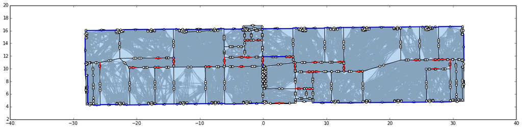

```python
S.L.showG('i',figsize=(20,20))
```

```
int0 :  (309, 15, 46)
int1 :  (202, 46, 59)
 output  {'(137, 59, 58)': 0.64242282168494413, '(230, 59, 67)': 0.35757717831506564, '(230, 59)': 0.35757717831506564}
 Sum pR :  0.357577178315
 Sum pT :  0.642422821685
lseg [137 230]
```

```
(-31.123950000000001, 34.74295, 3.6289500000000001, 17.468049999999998)
```

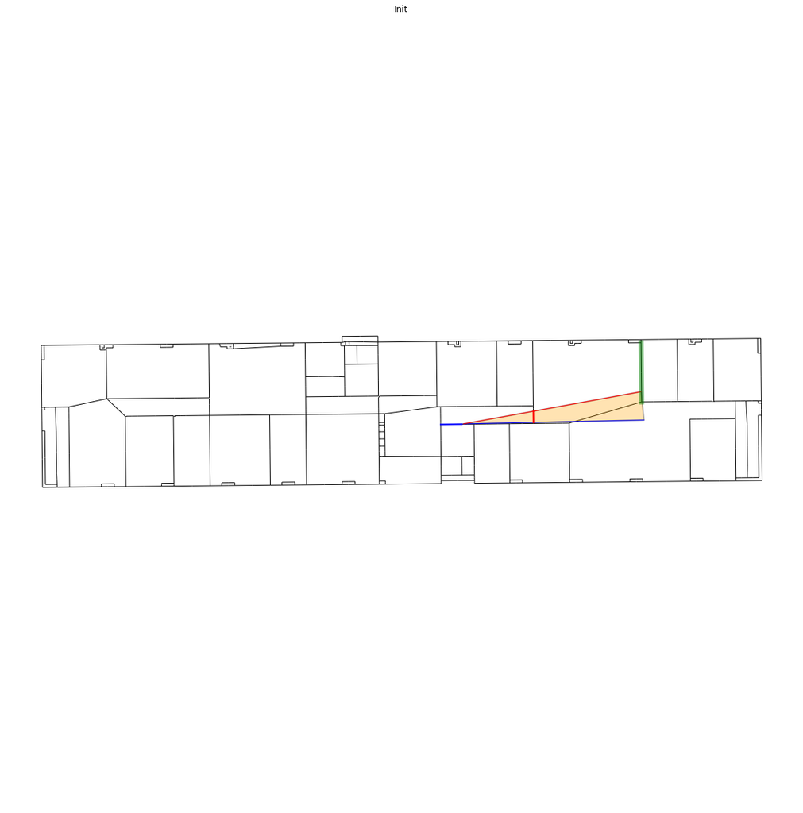

```python
figsize(20,20)
S.L.showGi(en=7)
axis('off')
```

The layout display is fully parameterized via the embedded **display** dictionnary member of the Layout object.

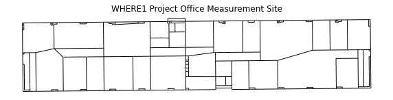

```python
figsize(10,10)
S.L.display['ednodes']=False
S.L.display['nodes']=False
S.L.display['title']='WHERE1 Project Office Measurement Site'
S.L.display['overlay']=False
fig,ax=S.L.showGs()
```

```python
S.L.Gi.edges()[0]
```

```
('(309, 15, 46)', '(148, 46, 44)')
```

## Adding coordinates of transmiting and receiving points

Coordinates of transmitters and receivers for the simulation to be perform are stotred in **.ini** files. Transmitter and Receiver are instances of the class `RadioNode` which offers different methods for specifying nodes positions. The stucture of this **.ini** file presented below. The node Id is associated with the 3 coordinates $x,y,z$ separated by white spaces.

```
[coordinates]
1 = -12.2724 7.76319999993 1.2
2 = -18.7747 15.1779999998 1.2
3 = -4.14179999998 8.86029999983 1.2
4 = -9.09139999998 15.1899000001 1.2
```

```python
S.tx = RadioNode(_fileini='w2m1rx.ini',_fileant='defant.vsh3')
S.rx = RadioNode(_fileini='w2m1tx.ini',_fileant='defant.vsh3')
```

The whole simulation setup can then be displayed using the **show** method of the Simulation object

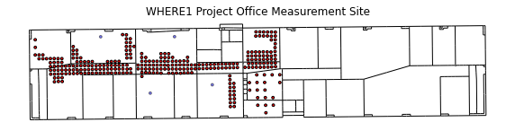

```python
fig,ax = S.show()
```

Select Tx and Rx positions

```python
map={1: 1,2: 2, 3: 3, 4: 5, 5: 6, 6: 7, 7: 8, 8: 9, 9: 10,
10: 11, 11: 12, 12: 13, 13: 14, 14: 15, 15: 16, 16: 17, 17: 18, 18: 19, 19: 20,
20: 21, 21: 22, 22: 23, 23: 24, 24: 25, 25: 26, 26: 27,
27: 28, 28: 29, 29: 30, 30: 32, 31: 33, 32: 34, 33: 35, 34: 36, 35: 37, 36: 38,
      37: 39, 38: 40, 39: 41, 40: 42, 41: 43, 42: 44, 43: 45, 44: 46, 45: 47,
      46: 48, 47: 49, 48: 50, 49: 51, 50: 52, 51: 53, 52: 54, 53: 55, 54: 56,
      55: 57, 56: 58, 57: 59, 58: 60, 59: 61, 60: 62, 61: 63, 62: 64, 63: 65,
      64: 66, 65: 67, 66: 68, 67: 69, 68: 70, 69: 71, 70: 72, 71: 73, 72: 74,
      73: 75, 74: 76, 75: 77, 76: 78, 77: 79, 78: 80, 79: 81, 80: 82, 81: 83,
      82: 84, 83: 85, 84: 89, 85: 90, 86: 91, 87: 92, 88: 93, 89: 94, 90: 95,
      91: 96, 92: 97, 93: 98, 94: 99, 95: 100, 96: 101, 97: 103, 98: 104, 99:
      105, 100: 106, 101: 107, 102: 108, 103: 109, 104: 110, 105: 111, 106:
      113, 107: 114, 108: 116, 109: 117, 110: 119, 111: 120, 112: 122, 113:
      123, 114: 124, 115: 125, 116: 126, 117: 127, 118: 128, 119: 129, 120:
      133, 121: 134, 122: 136, 123: 137, 124: 138, 125: 139, 126: 140, 127:
      141, 128: 142, 129: 143, 130: 144, 131: 145, 132: 146, 133: 147, 134:
      162, 135: 163, 136: 164, 137: 165, 138: 166, 139: 167, 140: 168, 141:
      169, 142: 170, 143: 171, 144: 172, 145: 173, 146: 174, 147: 175, 148:
      176, 149: 177, 150: 179, 151: 180, 152: 181, 153: 182, 154: 183, 155:
      184, 156: 185, 157: 186, 158: 188, 159: 189, 160: 199, 161: 200, 162:
      201, 163: 202, 164: 203, 165: 204, 166: 205, 167: 206, 168: 207, 169:
      208, 170: 209, 171: 210, 172: 211, 173: 212, 174: 213, 175: 214, 176:
      215, 177: 216, 178: 217, 179: 218, 180: 219, 181: 220, 182: 221, 183:
      222, 184: 223, 185: 227, 186: 228, 187: 229, 188: 230, 189: 231, 190:
      232, 191: 233, 192: 234, 193: 235, 194: 236, 195: 237, 196: 238, 197:
      239, 198: 240, 199: 241, 200: 242, 201: 243, 202: 244, 203: 245, 204:
      246, 205: 247, 206: 248, 207: 249, 208: 250, 209: 251, 210: 252, 211:
      253, 212: 258, 213: 259, 214: 266, 215: 267, 216: 268, 217: 269, 218:
      270, 219: 271, 220: 272, 221: 273, 222: 274, 223: 275, 224: 276, 225:
      277, 226: 278, 227: 279, 228: 297, 229: 298, 230: 299, 231: 300, 232:
      301, 233: 302, 234: 303, 235: 304, 236: 305, 237: 306, 238: 307, 239:
      308, 240: 309, 241: 310, 242: 311, 243: 312, 244: 313, 245: 314, 246:
      315, 247: 316, 248: 317, 249: 318, 250: 319, 251: 320, 252: 321, 253:
      322, 254: 323, 255: 324, 256: 325, 257: 326, 258: 327, 259: 328, 260:
      329, 261: 330, 262: 332, 263: 333, 264: 334, 265: 335, 266: 336, 267:
      337, 268: 338, 269: 339, 270: 340, 271: 341, 272: 342, 273: 343, 274:
      344, 275: 345, 276: 346, 277: 347, 278: 348, 279: 349, 280: 350, 281:
      351, 282: 352, 283: 353, 284: 354, 285: 355, 286: 356, 287: 360, 288:
      361, 289: 362, 290: 363, 291: 364, 292: 365, 293: 366, 294: 367, 295:
      368, 296: 369, 297: 370, 298: 371, 299: 372, 300: 373, 301: 374, 302:
      375}
```

```python
print 'number of Tx :',len(S.tx.points.keys())
print 'number of rx :',len(S.rx.points.keys())
```

```
number of Tx : 302
number of rx : 4
```

Choose measurement points

```python
# Chose used points here

itx=10
irx=2


# check points
tx= S.tx.points[itx]
rx= S.rx.points[irx]
M = UWBMeasure(map[itx])
txm = M.tx
rxm = M.rx[irx]
print tx,txm
print rx,rxm

if (tx[0] - txm[0] > 0.001) or (tx[1] - txm[1] > 0.001):
    print 'Tx and Txm Are not the same !!!!!!!!!!!!!!!!!!!!!!!!!!!!!!!!'
else :
    print 'Txs OK'
if (rx[0] - rxm[0] > 0.001) or (rx[1] - rxm[1] > 0.001):
    print 'Rx and Rxm Are not the same !!!!!!!!!!!!!!!!!!!!!!!!!!!!!!!!'
else :
    print 'Rxs OK'
```

```
[-24.867   12.3097   1.2   ] [-24.867   12.3097   1.2   ]
[-18.7747  15.178    1.2   ] [-18.7747  15.178    1.2   ]
Txs OK
Rxs OK
```

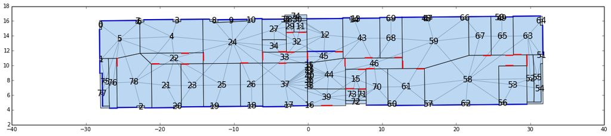

```python
fig =plt.figure(figsize=(20,20))
fig,ax=S.L.showG('t',fig=fig,labels=True)
```

```python
ax.plot(M.tx[0],M.tx[1],'or',label='tx')
ax.plot(M.rx[irx][0],M.rx[irx][1],'ob',label='rx')
ax.legend()
```

## Signatures, Rays and channel

A signature is a sequence of layout objects (points and segments) which are involved in a given optical ray joinint the transmiter and the receiver. The signatutre is calculated from a layout cycle to an other layout cycle. This means that is is required first to retrieve the cycle number from point coordinates. This is done thanks to the **pt2cy**, point to cycle function.

```python
ctx=S.L.pt2cy(tx)
crx=S.L.pt2cy(rx)
print 'tx point belongs to cycle ',ctx
print 'rx point belongs to cycle ',crx
```

```
tx point belongs to cycle  5
rx point belongs to cycle  4
```

Then the signature between cycle 5 and cycle 4 can be calculated. This is done by instantiating a Signature object with a given layout and the 2 cycle number.

```python
Si = Signatures(S.L,ctx,crx)
Si.run4(cutoff=3)
```

```python
tx[2]=1.5
```

```python
r2d = Si.rays(tx,rx)
r3d=r2d.to3D(S.L)
```

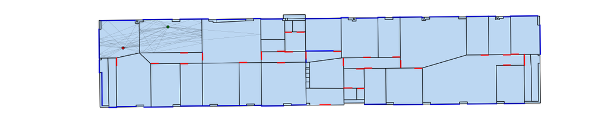

```python
r2d.show(S.L,figsize=(20,10),nodes=False)
```

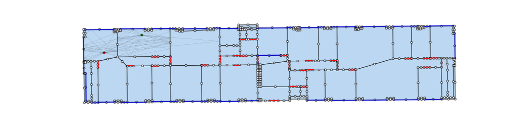

```python
r2d.show(S.L,figsize=(20,10))
```

```python
r3d.locbas(S.L)
r3d.fillinter(S.L)
r3d
```

```
Rays3D
----------
1 / 1 : [0]
2 / 5 : [1 2 3 4 5]
3 / 16 : [ 6  7  8  9 10 11 12 13 14 15 16 17 18 19 20 21]
4 / 30 : [22 23 24 25 26 27 28 29 30 31 32 33 34 35 36 37 38 39 40 41 42 43 44 45 46
 47 48 49 50 51]
5 / 32 : [52 53 54 55 56 57 58 59 60 61 62 63 64 65 66 67 68 69 70 71 72 73 74 75 76
 77 78 79 80 81 82 83]
6 / 16 : [84 85 86 87 88 89 90 91 92 93 94 95 96 97 98 99]
-----
ni : 435
nl : 970
```

```python
r3d
```

```
Rays3D
----------
1 / 1 : [0]
2 / 5 : [1 2 3 4 5]
3 / 16 : [ 6  7  8  9 10 11 12 13 14 15 16 17 18 19 20 21]
4 / 30 : [22 23 24 25 26 27 28 29 30 31 32 33 34 35 36 37 38 39 40 41 42 43 44 45 46
 47 48 49 50 51]
5 / 32 : [52 53 54 55 56 57 58 59 60 61 62 63 64 65 66 67 68 69 70 71 72 73 74 75 76
 77 78 79 80 81 82 83]
6 / 16 : [84 85 86 87 88 89 90 91 92 93 94 95 96 97 98 99]
-----
ni : 435
nl : 970
```

```python
S.freq()
```

```
array([  2.  ,   2.05,   2.1 ,   2.15,   2.2 ,   2.25,   2.3 ,   2.35,
         2.4 ,   2.45,   2.5 ,   2.55,   2.6 ,   2.65,   2.7 ,   2.75,
         2.8 ,   2.85,   2.9 ,   2.95,   3.  ,   3.05,   3.1 ,   3.15,
         3.2 ,   3.25,   3.3 ,   3.35,   3.4 ,   3.45,   3.5 ,   3.55,
         3.6 ,   3.65,   3.7 ,   3.75,   3.8 ,   3.85,   3.9 ,   3.95,
         4.  ,   4.05,   4.1 ,   4.15,   4.2 ,   4.25,   4.3 ,   4.35,
         4.4 ,   4.45,   4.5 ,   4.55,   4.6 ,   4.65,   4.7 ,   4.75,
         4.8 ,   4.85,   4.9 ,   4.95,   5.  ,   5.05,   5.1 ,   5.15,
         5.2 ,   5.25,   5.3 ,   5.35,   5.4 ,   5.45,   5.5 ,   5.55,
         5.6 ,   5.65,   5.7 ,   5.75,   5.8 ,   5.85,   5.9 ,   5.95,
         6.  ,   6.05,   6.1 ,   6.15,   6.2 ,   6.25,   6.3 ,   6.35,
         6.4 ,   6.45,   6.5 ,   6.55,   6.6 ,   6.65,   6.7 ,   6.75,
         6.8 ,   6.85,   6.9 ,   6.95,   7.  ,   7.05,   7.1 ,   7.15,
         7.2 ,   7.25,   7.3 ,   7.35,   7.4 ,   7.45,   7.5 ,   7.55,
         7.6 ,   7.65,   7.7 ,   7.75,   7.8 ,   7.85,   7.9 ,   7.95,
         8.  ,   8.05,   8.1 ,   8.15,   8.2 ,   8.25,   8.3 ,   8.35,
         8.4 ,   8.45,   8.5 ,   8.55,   8.6 ,   8.65,   8.7 ,   8.75,
         8.8 ,   8.85,   8.9 ,   8.95,   9.  ,   9.05,   9.1 ,   9.15,
         9.2 ,   9.25,   9.3 ,   9.35,   9.4 ,   9.45,   9.5 ,   9.55,
         9.6 ,   9.65,   9.7 ,   9.75,   9.8 ,   9.85,   9.9 ,   9.95,
        10.  ,  10.05,  10.1 ,  10.15,  10.2 ,  10.25,  10.3 ,  10.35,
        10.4 ,  10.45,  10.5 ,  10.55,  10.6 ,  10.65,  10.7 ,  10.75,
        10.8 ,  10.85,  10.9 ,  10.95,  11.  ])
```

```python
Ct = r3d.eval(S.freq())
```

The `energy` method calculates the energy hoeld by each ray

```python
Ct.energy()
```

```
(array([  2.19954455e-07,   1.36579180e-07,   1.17899852e-07,
          8.51486449e-09,   9.61881061e-09,   9.64823678e-09,
          5.43456762e-09,   4.69402578e-09,   1.60256241e-09,
          1.84751543e-09,   2.07034427e-09,   7.88790226e-09,
          9.28452904e-09,   2.01351852e-11,   5.61797262e-11,
          8.14092539e-09,   1.43067548e-10,   7.79904043e-09,
          1.60961650e-10,   1.23770591e-09,   7.69122187e-10,
          1.32195363e-09,   7.19626346e-11,   1.56937090e-10,
          1.76315168e-09,   1.70671456e-09,   1.63390924e-12,
          1.08726484e-11,   1.92742585e-11,   9.92248231e-10,
          2.58605904e-11,   4.00521411e-09,   6.25988801e-12,
          1.40737821e-10,   1.45101925e-10,   9.61318787e-12,
          3.09462403e-13,   1.74402052e-09,   1.96292255e-09,
          2.42817149e-11,   1.03096142e-12,   3.32659357e-11,
          1.51148731e-12,   2.08993268e-11,   2.22840595e-11,
          5.15438190e-11,   3.02707163e-12,   1.31487914e-10,
          3.17622744e-11,   1.82051240e-10,   1.42451677e-10,
          2.89473435e-10,   2.78878940e-10,   1.99779444e-10,
          1.28777166e-11,   1.87460986e-11,   2.06512068e-11,
          4.91234707e-12,   5.48945667e-12,   4.64838070e-11,
          2.33700978e-11,   3.08866534e-12,   3.85157127e-11,
          1.93330939e-11,   3.61888250e-12,   1.81238119e-11,
          9.21826309e-10,   3.12554434e-10,   8.58046727e-12,
          6.47284551e-10,   7.23482333e-12,   1.36413160e-11,
          5.68611445e-12,   1.95064893e-10,   2.76091297e-11,
          7.97359641e-12,   3.26590923e-10,   3.76839430e-10,
          1.67631988e-10,   4.15220913e-11,   3.72736654e-11,
          3.95993445e-11,   7.94286569e-11,   6.20069374e-11,
          3.03537182e-13,   2.63675592e-12,   5.91493799e-12,
          3.30084035e-11,   2.27682935e-11,   8.53134362e-13,
          1.15860491e-12,   2.18836230e-12,   7.42167663e-12,
          1.29254813e-11,   1.29565047e-10,   1.25540575e-10,
          1.31917946e-10,   1.02165639e-10,   2.03400601e-10,
          1.95076759e-10]),
 array([  1.88824569e-07,   2.15111951e-08,   2.72204948e-08,
          4.19059189e-08,   1.00593183e-08,   9.77625853e-09,
          3.46446133e-09,   4.27609825e-09,   2.33341044e-09,
          3.12826459e-09,   1.56243992e-09,   7.04193751e-10,
          7.17384005e-10,   4.79905639e-09,   3.99056923e-09,
          8.73343902e-10,   6.43447500e-09,   6.72455259e-10,
```

[output cut: 81 more lines]

```
          3.26028634e-11,   5.06316202e-11,   8.53567507e-12,
          1.69890259e-11,   3.84880232e-10,   1.89905106e-11,
          7.74629538e-12,   4.37341162e-10,   9.92337567e-12,
          5.57475724e-14,   7.04692578e-11,   2.39802425e-12,
          1.59111295e-14,   2.97468083e-12,   5.28680146e-11,
          3.24890054e-10,   2.65661336e-11,   1.96985129e-11,
          1.14447142e-10,   4.61435065e-11,   3.98223586e-11,
          2.05730511e-14,   2.93299384e-12,   6.21973278e-14,
          1.71905475e-12,   2.71642001e-13,   2.03035901e-12,
          5.26440799e-12,   6.32352145e-12,   2.59907385e-12,
          2.18857339e-13,   3.86508775e-15,   2.32554095e-11,
          1.91459286e-12,   2.31650439e-11,   7.44577473e-12,
          7.00958397e-12,   2.56722372e-14,   2.83859910e-14,
          1.87600534e-14,   1.45466058e-14,   1.17569688e-14,
          1.36132272e-14]))
```

## Apply waveform

```python
Ct.freq = S.freq
sco= Ct.prop2tran(a='theta',b='theta')
sca= Ct.prop2tran(a=S.tx.A,b=S.rx.A)
```

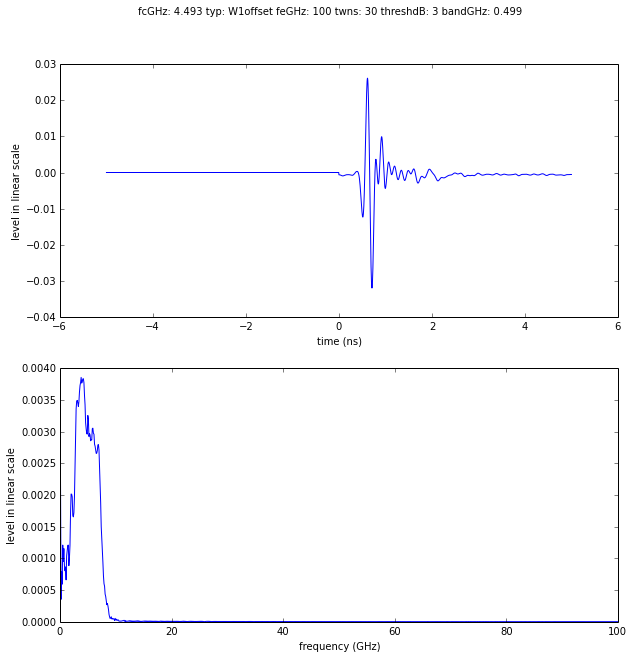

```python
wav = wvf.Waveform(typ='W1offset')
#wav = wvf.Waveform({'type' : 'generic','band': 0.499,'fc': 4.493, 'fe': 100, 'thresh': 3, 'tw': 30})
wav.show()
```

```python
sco.isFriis
```

```
True
```

```python
if sco.isFriis:
    ciro = sco.applywavB(wav.sf)
else:
    ciro = sco.applywavB(wav.sfg)
if sca.isFriis:
    cira = sca.applywavB(wav.sf)
else:
     cira = sca.applywavB(wav.sfg)
```

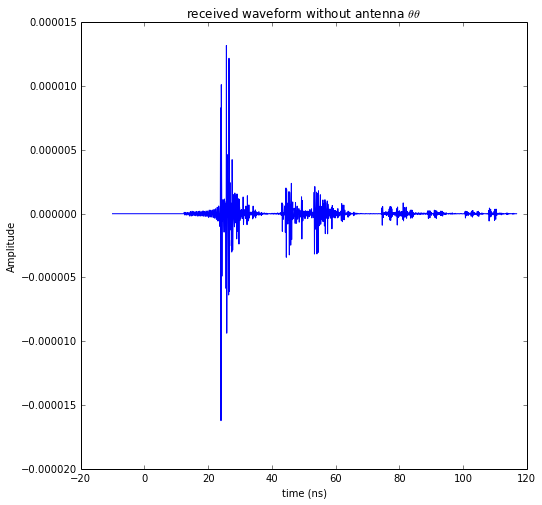

```python
ciro.plot(typ='v')
title(u'received waveform without antenna $\\theta\\theta$')
```

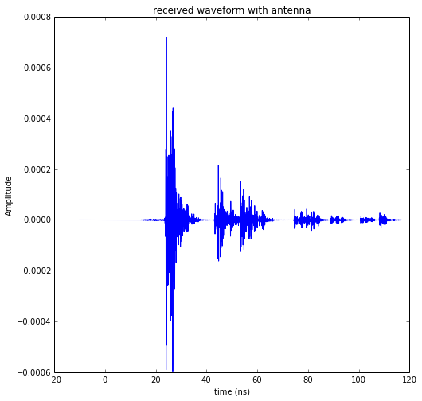

```python
cira.plot(typ='v')
title('received waveform with antenna')
```

```python
#dchan={i:'ch'+str(i) for i in range(1,5)}
dchan={}
dchan[1]='ch3'
dchan[2]='ch4'
dchan[3]='ch1'
dchan[4]='ch2'
```

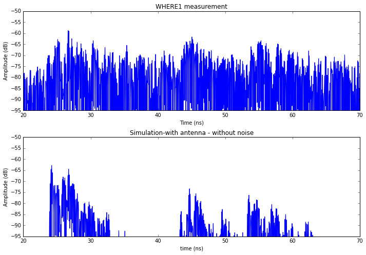

```python
fig = plt.figure()
ax1 = fig.add_subplot(311,title="Measurements")
cmd='M.tdd.' + str(dchan[irx]) + '.plot(ax=ax1)'
eval(cmd)
title('WHERE1 measurement')
#M.tdd.ch2.plot()
# align for plotting
#ciro.x=ciro.x-ciro.x[0]
ax2 = fig.add_subplot(312,title="Simulation-with antenna",sharex=ax1, sharey=ax1)
plt.xlim(20,70)
plt.ylim(-95,-50)
u = cira.plot(ax=ax2)
title('Simulation-with antenna - without noise')
plt.tight_layout()
#ax3 = fig.add_subplot(313,title="Simulation-without antenna",sharex=ax1, sharey=ax1)
#ciro.plot()
```

```python
v = tx-rx
d = sqrt(dot(v,v))

print 'real delay between tx and rx',d/0.3
print 'simulated first path delay',r3d.delays[0]
```

```
real delay between tx and rx 22.4680672606
simulated first path delay 22.4680672606
```

```python
r3d.delays
```

```
array([  22.46806726,   24.18292882,   24.99628065,   25.87437157,
         42.95559158,   51.79056452,   27.37668906,   28.09774198,
         29.40772086,   30.73782761,   41.71071752,   43.87690563,
         44.3303829 ,   44.83132695,   45.78534275,   52.55723141,
         52.83546805,   52.93640121,   53.35513533,   57.24533827,
         73.04881379,   77.74128409,   32.08555912,   33.30890428,
         42.65892586,   43.12521253,   45.714854  ,   46.15027493,
         46.65080504,   46.95937444,   47.07757014,   47.80358614,
         48.77327119,   53.58718769,   53.95912049,   54.09963462,
         54.46806832,   55.15670923,   55.87720978,   56.27546336,
         57.93987188,   58.28403515,   73.59435574,   73.8656158 ,
         74.74796992,   75.18892262,   78.25411972,   78.44138572,
         78.50928131,   87.50257849,   99.12940895,  104.69401317,
         45.82339965,   46.68815648,   48.68108335,   49.49593798,
         49.56104933,   49.58661092,   49.98831846,   50.36166807,
         56.13899433,   56.62835391,   56.8470464 ,   56.9818197 ,
         57.33036252,   57.33173446,   60.30778352,   60.96744011,
         75.28119956,   75.47270498,   75.54640301,   75.71904704,
         75.98272228,   76.00084997,   78.9496738 ,   79.20259461,
         80.02316697,   80.52147075,   87.95852001,   88.18560678,
         99.53210396,   99.73284172,  105.07538433,  105.26555179,
         52.33385121,   53.09267353,   59.38794302,   60.05770372,
         77.11847384,   77.54594822,   77.63542367,   78.06006716,
         80.70347572,   81.19760461,   89.53603321,   89.98167171,
        100.92888446,  101.32442804,  106.39941914,  106.77469922])
```

```python
r3d.info(0)
```

```
-------------------------
Informations of ray # 0
-------------------------

Index , type, slab      , th(rad), alpha     , gamma2
    0 , B0  , -         , -      , -         , -
    0 , T   , PARTITION ,    0.43,  (0.35+0j),  (0.88+0j)
    0 , B   , -         , -      , -         , -

----------------------------------------
 Matrix of ray # 0 at f= 2.0
----------------------------------------
rotation matrix# type: B0
[[-0.99533359 -0.09649373]
 [ 0.09649373 -0.99533359]]
interaction # 0 type: T
[[ 0.29697185+0.47269683j  0.00000000+0.j        ]
 [ 0.00000000+0.j          0.34443500+0.50490218j]]
rotation matrix# [0] type: B
[[ 0.99533359  0.09649373]
 [-0.09649373  0.99533359]]
```

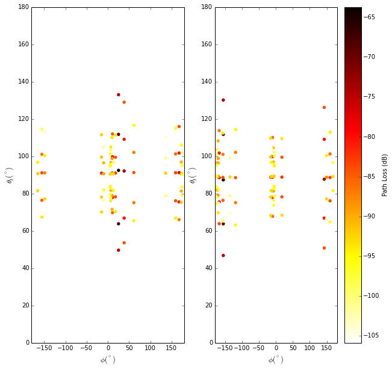

```python
Ct.doadod(phi=(-180,180))
```